# Ch5 Cartels

Jing Fang

# Ch5 Cartels

- In any market, firms have an incentive to coordinate their production and pricing activities to increase their collective and individual profits by restricting market output and raising the market price.
- An association of firms that explicitly coordinates its pricing or output activities is called a **cartel**.

# Ch5 Cartels

- Cartels are more likely to occur in oligopolistic markets.
- Fortunately for consumers, although firms have an incentive to coordinate activities, each member of the cartel has an incentive to “cheat” on the cartel agreement.
- When a cartel partially breaks apart so that some firms act outside of the cartel, the cartel may act like a dominant firm facing a competitive fringe of nonmember firms.

# Ch5 Cartels

- Four key questions are examined in this chapter:
  1. Why do cartels form?
  2. What factors cause some cartels to last and others to break up, even without government intervention?
  3. How harmful are cartels?
  4. What have governments done about cartels?

# Why Cartels Form

# Why Cartels Form

- The answer is that each individual firm wants to increase its own profit.
- But how can the firms to better by forming a cartel if each is already maximizing its profit?
- In a competitive market, each firm considers how much a reduction in its own benefits it and ignores the gains to other firms.
- In contrast, a cartel takes into account the benefits to all its members of the reduction in each firm’s output.

# Why Cartels Form

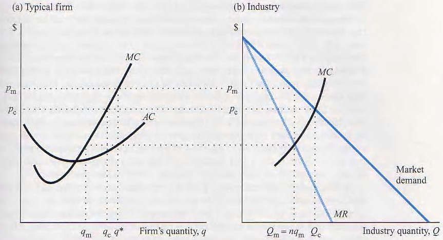

# Why Cartels Form

- If all firms cut back by 10%, the market price definitely rises.
- However, if only one firm cuts back by 10%, the effect on price is so small that it is hardly to measure.
- A competitive firm ignores the good it does other firms by reducing its output and increasing the market price。
- It places no value on the gains of other firms.
- This gain by others is an externality.

# Creating and Enforcing the Cartel

# Creating and Enforcing the Cartel

- Discuss:
  - Would you join a cartel if all the other firms in your market were forming one?

# Creating and Enforcing the Cartel

- Once a cartel forms, the firms must agree to fix price (or equivalently, reduce output) if it is to be successful.
- Three major factors are necessary to establish a cartel.
  - **The ability to raise the market price.**
  - **Low expectation of severe punishment.**
  - **Low organizational costs.**

# Creating and Enforcing the Cartel

- **The ability to raise the market price.**
- Only if a cartel is expected to raise the price above the noncartel price and keep it high do firms join.
- Entry by nonmember firms or close substitutes produced in other industries prevents a cartel from raising price.

# Creating and Enforcing the Cartel

- **Low expectation of severe punishment.**
- Cartels only from if members do not expect the government to catch and severely punish them.

# Creating and Enforcing the Cartel

- **Low organizational costs.**
- Even if a potential cartel could raise prices in the LR and not be discovered, it will not form if the cost of initial organization is too high.
- Four factors keep the cost low:
  - Few firms are involved
  - The Market is highly concentrated
  - All firms produce a nearly identical product
  - A trade association exists.

# Enforcing the Cartel

- Even if a market consists of a small number of firms producing a homogeneous good with no close substitutes, has an inelastic demand curve, and faces no threat of entry, a cartel cannot succeed if members can and want to cheat on the agreement.

# Enforcing the Cartel

- Cartel agreements are easier to enforce if detecting violations is easy.
- Four factors aid in the detection of cheating:
  1. There are few firms in the market.
  2. Prices do not fluctuate independently.
  3. Prices are widely known
  4. All cartel members sell identical products at the same point in the distribution chain.

# Enforcing the Cartel

- A cartel may find enforcement easy under certain circumstances.
- Members have no incentive to cheat on the cartel agreement if:
  1. MC curves are relatively inelastic.
  2. FC are low relative to TC.
  3. Customers place small, frequent orders.
  4. They have a single sales agent.

# Enforcing the Cartel

- To prevent cheating, successful cartels must do more than just set a price.
  - Some cartels succeed in preventing cheating by assigning each firm certain buyers or geographic areas, which allows cheating to be easily detected.
  - Another effective technique is for members of a cartel to agree to fix market shares.

# Enforcing the Cartel

- A **most-favored-nation** clause in a sales contract guarantees the buyer that the seller is not selling at a lower price to another buyer.
- A **meeting-competition** clause in a LR supply contract or in an advertisement guarantees the buyer that if another firm offers a lower price, the seller will match it or release the buyer from the contract.

# Enforcing the Cartel

- All cartel members could agree that if the market price drops below a certain level (called a trigger price), each firm will expand its output to the precartel level; that is all firms will abandon the cartel agreement.

# Consumers Gain as Cartels Fail

# Consumers Gain as Cartels Fail

- How price and output vary with the number of cartel members.
- The total number of firms is assumed to be fixed at n.
- The market demand curve is linear: $Q_d=a-bp$ where $a,b>0$
- The elasticity of demand is:
  $$\varepsilon=\frac{dQ}{dp}\frac{p}{Q}=\frac{-bp}{a-bp}$$

# Consumers Gain as Cartels Fail

- Each firm has a linear MC: $MC=d+eq$ where $d,e>0$
- As a result, the competitive supply ($p=MC$) is:
  $$Q_s=nq=\frac{n(p-d)}{e}$$
- At CE, $Q_s=Q_d$, so the equilibrium values are:
  $$\begin{matrix}
  p_c & = & \frac{ae+nd}{be+n} \\
  Q_c & = & n(\frac{a-bd}{be+n})
  \end{matrix}$$

# Consumers Gain as Cartels Fail

- Now suppose that n-j firms in the market form a cartel and the remaining j firms do not. The residual demand $Q_r$ is:
  $$Q_r=Q-jq=a-bp-\frac{j(p-d)}{e}$$
- The cartel acts as a monopoly and its marginal revenue (MR) is:
  $$\begin{matrix}
  R_m & = & pQ_r=(\frac{ae+jd-eQ_r}{be+j})Q_r \\
  MR_m & = & \frac{ae+jd}{be+j}-\frac{2eQ_r}{be+j}
  \end{matrix}$$

# Consumers Gain as Cartels Fail

- The cartel’s MC is:
  $$MC_m=d+\frac{e}{n-j}Q_m$$
- The quantity the cartel chooses to produce is determined by $MR=MC$:
  $$Q_m=Q_r=\frac{(n-j)(a-bd)}{be+2n-j}$$

# Consumers Gain as Cartels Fail

- By differentiating $Q_m$ with respect to j, it can be shown that the cartel’s output falls as the number of nonmember firms rises.
  $$\frac{\partial Q_m}{\partial j}=\frac{-(be+n)(a-bd)}{(be+2n-j)^2}$$
- As the cartel gains members, the incentive of a cartel firm to cheat also grows.
- Consumers benefit if firm refuse to join the cartel.